# QTreeView Class

The QTreeView class provides a default model/view implementation of a tree view. More...

| Header: | `#include <QTreeView>` |
| --- | --- |
| CMake: | `find_package(Qt6 REQUIRED COMPONENTS Widgets)` `target_link_libraries(mytarget PRIVATE Qt6::Widgets)` |
| qmake: | `QT += widgets` |
| Inherits: | QAbstractItemView |
| Inherited By: | QHelpContentWidget and QTreeWidget |

- [List of all members, including inherited members](https://doc.qt.io/qt-6.9/qtreeview-members.html)

## Properties

- **allColumnsShowFocus** : bool
- **animated** : bool
- **autoExpandDelay** : int
- **expandsOnDoubleClick** : bool
- **headerHidden** : bool
- **indentation** : int
- **itemsExpandable** : bool
- **rootIsDecorated** : bool
- **sortingEnabled** : bool
- **uniformRowHeights** : bool
- **wordWrap** : bool

## Public Functions

|  | **QTreeView**(QWidget **parent* = nullptr) |
| --- | --- |
| virtual | **~QTreeView**() |
| bool | **allColumnsShowFocus**() const |
| int | **autoExpandDelay**() const |
| int | **columnAt**(int *x*) const |
| int | **columnViewportPosition**(int *column*) const |
| int | **columnWidth**(int *column*) const |
| bool | **expandsOnDoubleClick**() const |
| QHeaderView * | **header**() const |
| int | **indentation**() const |
| QModelIndex | **indexAbove**(const QModelIndex &*index*) const |
| QModelIndex | **indexBelow**(const QModelIndex &*index*) const |
| bool | **isAnimated**() const |
| bool | **isColumnHidden**(int *column*) const |
| bool | **isExpanded**(const QModelIndex &*index*) const |
| bool | **isFirstColumnSpanned**(int *row*, const QModelIndex &*parent*) const |
| bool | **isHeaderHidden**() const |
| bool | **isRowHidden**(int *row*, const QModelIndex &*parent*) const |
| bool | **isSortingEnabled**() const |
| bool | **itemsExpandable**() const |
| void | **resetIndentation**() |
| bool | **rootIsDecorated**() const |
| void | **setAllColumnsShowFocus**(bool *enable*) |
| void | **setAnimated**(bool *enable*) |
| void | **setAutoExpandDelay**(int *delay*) |
| void | **setColumnHidden**(int *column*, bool *hide*) |
| void | **setColumnWidth**(int *column*, int *width*) |
| void | **setExpanded**(const QModelIndex &*index*, bool *expanded*) |
| void | **setExpandsOnDoubleClick**(bool *enable*) |
| void | **setFirstColumnSpanned**(int *row*, const QModelIndex &*parent*, bool *span*) |
| void | **setHeader**(QHeaderView **header*) |
| void | **setHeaderHidden**(bool *hide*) |
| void | **setIndentation**(int *i*) |
| void | **setItemsExpandable**(bool *enable*) |
| void | **setRootIsDecorated**(bool *show*) |
| void | **setRowHidden**(int *row*, const QModelIndex &*parent*, bool *hide*) |
| void | **setSortingEnabled**(bool *enable*) |
| void | **setTreePosition**(int *index*) |
| void | **setUniformRowHeights**(bool *uniform*) |
| void | **setWordWrap**(bool *on*) |
| int | **treePosition**() const |
| bool | **uniformRowHeights**() const |
| bool | **wordWrap**() const |

## Reimplemented Public Functions

| virtual void | **dataChanged**(const QModelIndex &*topLeft*, const QModelIndex &*bottomRight*, const QList<int> &*roles* = QList<int>()) override |
| --- | --- |
| virtual QModelIndex | **indexAt**(const QPoint &*point*) const override |
| virtual void | **keyboardSearch**(const QString &*search*) override |
| virtual void | **reset**() override |
| virtual void | **scrollTo**(const QModelIndex &*index*, QAbstractItemView::ScrollHint *hint* = EnsureVisible) override |
| virtual void | **selectAll**() override |
| virtual void | **setModel**(QAbstractItemModel **model*) override |
| virtual void | **setRootIndex**(const QModelIndex &*index*) override |
| virtual void | **setSelectionModel**(QItemSelectionModel **selectionModel*) override |
| virtual QRect | **visualRect**(const QModelIndex &*index*) const override |

## Public Slots

| void | **collapse**(const QModelIndex &*index*) |
| --- | --- |
| void | **collapseAll**() |
| void | **expand**(const QModelIndex &*index*) |
| void | **expandAll**() |
| void | **expandRecursively**(const QModelIndex &*index*, int *depth* = -1) |
| void | **expandToDepth**(int *depth*) |
| void | **hideColumn**(int *column*) |
| void | **resizeColumnToContents**(int *column*) |
| void | **showColumn**(int *column*) |
| void | **sortByColumn**(int *column*, Qt::SortOrder *order*) |

## Signals

| void | **collapsed**(const QModelIndex &*index*) |
| --- | --- |
| void | **expanded**(const QModelIndex &*index*) |

## Protected Functions

| virtual void | **drawBranches**(QPainter **painter*, const QRect &*rect*, const QModelIndex &*index*) const |
| --- | --- |
| virtual void | **drawRow**(QPainter **painter*, const QStyleOptionViewItem &*option*, const QModelIndex &*index*) const |
| void | **drawTree**(QPainter **painter*, const QRegion &*region*) const |
| int | **indexRowSizeHint**(const QModelIndex &*index*) const |
| int | **rowHeight**(const QModelIndex &*index*) const |

## Reimplemented Protected Functions

| virtual void | **changeEvent**(QEvent **event*) override |
| --- | --- |
| virtual void | **currentChanged**(const QModelIndex &*current*, const QModelIndex &*previous*) override |
| virtual void | **dragMoveEvent**(QDragMoveEvent **event*) override |
| virtual int | **horizontalOffset**() const override |
| virtual bool | **isIndexHidden**(const QModelIndex &*index*) const override |
| virtual void | **keyPressEvent**(QKeyEvent **event*) override |
| virtual void | **mouseDoubleClickEvent**(QMouseEvent **event*) override |
| virtual void | **mouseMoveEvent**(QMouseEvent **event*) override |
| virtual void | **mousePressEvent**(QMouseEvent **event*) override |
| virtual void | **mouseReleaseEvent**(QMouseEvent **event*) override |
| virtual QModelIndex | **moveCursor**(QAbstractItemView::CursorAction *cursorAction*, Qt::KeyboardModifiers *modifiers*) override |
| virtual void | **paintEvent**(QPaintEvent **event*) override |
| virtual void | **rowsAboutToBeRemoved**(const QModelIndex &*parent*, int *start*, int *end*) override |
| virtual void | **rowsInserted**(const QModelIndex &*parent*, int *start*, int *end*) override |
| virtual void | **scrollContentsBy**(int *dx*, int *dy*) override |
| virtual QModelIndexList | **selectedIndexes**() const override |
| virtual void | **selectionChanged**(const QItemSelection &*selected*, const QItemSelection &*deselected*) override |
| virtual void | **setSelection**(const QRect &*rect*, QItemSelectionModel::SelectionFlags *command*) override |
| virtual int | **sizeHintForColumn**(int *column*) const override |
| virtual void | **timerEvent**(QTimerEvent **event*) override |
| virtual void | **updateGeometries**() override |
| virtual int | **verticalOffset**() const override |
| virtual bool | **viewportEvent**(QEvent **event*) override |
| virtual QSize | **viewportSizeHint**() const override |
| virtual QRegion | **visualRegionForSelection**(const QItemSelection &*selection*) const override |

## Protected Slots

| void | **columnCountChanged**(int *oldCount*, int *newCount*) |
| --- | --- |
| void | **columnMoved**() |
| void | **columnResized**(int *column*, int *oldSize*, int *newSize*) |
| void | **rowsRemoved**(const QModelIndex &*parent*, int *start*, int *end*) |

## Detailed Description

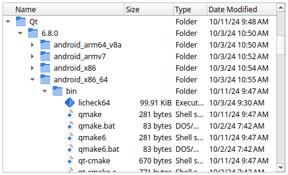

A QTreeView implements a tree representation of items from a model. This class is used to provide standard hierarchical lists that were previously provided by the `QListView` class, but using the more flexible approach provided by Qt's model/view architecture.

The QTreeView class is one of the Model/View Classes and is part of Qt's model/view framework.

QTreeView implements the interfaces defined by the QAbstractItemView class to allow it to display data provided by models derived from the QAbstractItemModel class.

It is simple to construct a tree view displaying data from a model. In the following example, the contents of a directory are supplied by a QFileSystemModel and displayed as a tree:

```
    QFileSystemModel *model = new QFileSystemModel;
    model->setRootPath(QDir::currentPath());
    QTreeView *tree = new QTreeView(splitter);
    tree->setModel(model);
```

The model/view architecture ensures that the contents of the tree view are updated as the model changes.

Items that have children can be in an expanded (children are visible) or collapsed (children are hidden) state. When this state changes a collapsed() or expanded() signal is emitted with the model index of the relevant item.

The amount of indentation used to indicate levels of hierarchy is controlled by the indentation property.

Headers in tree views are constructed using the QHeaderView class and can be hidden using `header()->hide()`. Note that each header is configured with its stretchLastSection property set to true, ensuring that the view does not waste any of the space assigned to it for its header. If this value is set to true, this property will override the resize mode set on the last section in the header.

By default, all columns in a tree view are movable except the first. To disable movement of these columns, use QHeaderView's setSectionsMovable() function. For more information about rearranging sections, see Moving Header Sections.

### Key Bindings

QTreeView supports a set of key bindings that enable the user to navigate in the view and interact with the contents of items:

[output not shown]

### Improving Performance

It is possible to give the view hints about the data it is handling in order to improve its performance when displaying large numbers of items. One approach that can be taken for views that are intended to display items with equal heights is to set the uniformRowHeights property to true.

**See also** QListView, QTreeWidget, View Classes, QAbstractItemModel, and QAbstractItemView.

## Property Documentation

### allColumnsShowFocus : bool

This property holds whether items should show keyboard focus using all columns

If this property is `true` all columns will show focus, otherwise only one column will show focus.

The default is false.

**Access functions:**

| bool | **allColumnsShowFocus**() const |
| --- | --- |
| void | **setAllColumnsShowFocus**(bool *enable*) |

### animated : bool

This property holds whether animations are enabled

If this property is `true` the treeview will animate expansion and collapsing of branches. If this property is `false`, the treeview will expand or collapse branches immediately without showing the animation.

By default, this property is `false`.

**Access functions:**

| bool | **isAnimated**() const |
| --- | --- |
| void | **setAnimated**(bool *enable*) |

### autoExpandDelay : int

This property holds the delay time before items in a tree are opened during a drag and drop operation.

This property holds the amount of time in milliseconds that the user must wait over a node before that node will automatically open. If the time is set to less then 0 then it will not be activated.

By default, this property has a value of -1, meaning that auto-expansion is disabled.

**Access functions:**

| int | **autoExpandDelay**() const |
| --- | --- |
| void | **setAutoExpandDelay**(int *delay*) |

### expandsOnDoubleClick : bool

This property holds whether the items can be expanded by double-clicking.

This property holds whether the user can expand and collapse items by double-clicking. The default value is true.

**Access functions:**

| bool | **expandsOnDoubleClick**() const |
| --- | --- |
| void | **setExpandsOnDoubleClick**(bool *enable*) |

**See also** itemsExpandable.

### headerHidden : bool

This property holds whether the header is shown or not.

If this property is `true`, the header is not shown otherwise it is. The default value is false.

**Access functions:**

| bool | **isHeaderHidden**() const |
| --- | --- |
| void | **setHeaderHidden**(bool *hide*) |

**See also** header().

### indentation : int

indentation of the items in the tree view.

This property holds the indentation measured in pixels of the items for each level in the tree view. For top-level items, the indentation specifies the horizontal distance from the viewport edge to the items in the first column; for child items, it specifies their indentation from their parent items.

By default, the value of this property is style dependent. Thus, when the style changes, this property updates from it. Calling setIndentation() stops the updates, calling resetIndentation() will restore default behavior.

**Access functions:**

| int | **indentation**() const |
| --- | --- |
| void | **setIndentation**(int *i*) |
| void | **resetIndentation**() |

### itemsExpandable : bool

This property holds whether the items are expandable by the user.

This property holds whether the user can expand and collapse items interactively.

By default, this property is `true`.

**Access functions:**

| bool | **itemsExpandable**() const |
| --- | --- |
| void | **setItemsExpandable**(bool *enable*) |

### rootIsDecorated : bool

This property holds whether to show controls for expanding and collapsing top-level items

Items with children are typically shown with controls to expand and collapse them, allowing their children to be shown or hidden. If this property is false, these controls are not shown for top-level items. This can be used to make a single level tree structure appear like a simple list of items.

By default, this property is `true`.

**Access functions:**

| bool | **rootIsDecorated**() const |
| --- | --- |
| void | **setRootIsDecorated**(bool *show*) |

### sortingEnabled : bool

This property holds whether sorting is enabled

If this property is `true`, sorting is enabled for the tree; if the property is false, sorting is not enabled. The default value is false.

**Note:** In order to avoid performance issues, it is recommended that sorting is enabled *after* inserting the items into the tree. Alternatively, you could also insert the items into a list before inserting the items into the tree.

**Access functions:**

| bool | **isSortingEnabled**() const |
| --- | --- |
| void | **setSortingEnabled**(bool *enable*) |

**See also** sortByColumn().

### uniformRowHeights : bool

This property holds whether all items in the treeview have the same height

This property should only be set to true if it is guaranteed that all items in the view has the same height. This enables the view to do some optimizations.

The height is obtained from the first item in the view. It is updated when the data changes on that item.

**Note:** If the editor size hint is bigger than the cell size hint, then the size hint of the editor will be used.

By default, this property is `false`.

**Access functions:**

| bool | **uniformRowHeights**() const |
| --- | --- |
| void | **setUniformRowHeights**(bool *uniform*) |

### wordWrap : bool

This property holds the item text word-wrapping policy

If this property is `true` then the item text is wrapped where necessary at word-breaks; otherwise it is not wrapped at all. This property is `false` by default.

Note that even if wrapping is enabled, the cell will not be expanded to fit all text. Ellipsis will be inserted according to the current textElideMode.

**Access functions:**

| bool | **wordWrap**() const |
| --- | --- |
| void | **setWordWrap**(bool *on*) |

## Member Function Documentation

### `[explicit]` QTreeView::QTreeView(QWidget **parent* = nullptr)

Constructs a tree view with a *parent* to represent a model's data. Use setModel() to set the model.

**See also** QAbstractItemModel.

### `[virtual noexcept]` QTreeView::~QTreeView()

Destroys the tree view.

### `[override virtual protected]` void QTreeView::changeEvent(QEvent **event*)

Reimplements: QFrame::changeEvent(QEvent *ev).

### `[slot]` void QTreeView::collapse(const QModelIndex &*index*)

Collapses the model item specified by the *index*.

**See also** collapsed().

### `[slot]` void QTreeView::collapseAll()

Collapses all expanded items.

**See also** expandAll(), expand(), collapse(), and setExpanded().

### `[signal]` void QTreeView::collapsed(const QModelIndex &*index*)

This signal is emitted when the item specified by *index* is collapsed.

### int QTreeView::columnAt(int *x*) const

Returns the column in the tree view whose header covers the *x* coordinate given.

### `[protected slot]` void QTreeView::columnCountChanged(int *oldCount*, int *newCount*)

Informs the tree view that the number of columns in the tree view has changed from *oldCount* to *newCount*.

### `[protected slot]` void QTreeView::columnMoved()

This slot is called whenever a column has been moved.

### `[protected slot]` void QTreeView::columnResized(int *column*, int *oldSize*, int *newSize*)

This function is called whenever *column*'s size is changed in the header. *oldSize* and *newSize* give the previous size and the new size in pixels.

**See also** setColumnWidth().

### int QTreeView::columnViewportPosition(int *column*) const

Returns the horizontal position of the *column* in the viewport.

### int QTreeView::columnWidth(int *column*) const

Returns the width of the *column*.

**See also** resizeColumnToContents() and setColumnWidth().

### `[override virtual protected]` void QTreeView::currentChanged(const QModelIndex &*current*, const QModelIndex &*previous*)

Reimplements: QAbstractItemView::currentChanged(const QModelIndex &current, const QModelIndex &previous).

### `[override virtual]` void QTreeView::dataChanged(const QModelIndex &*topLeft*, const QModelIndex &*bottomRight*, const QList<int> &*roles* = QList<int>())

Reimplements: QAbstractItemView::dataChanged(const QModelIndex &topLeft, const QModelIndex &bottomRight, const QList<int> &roles).

### `[override virtual protected]` void QTreeView::dragMoveEvent(QDragMoveEvent **event*)

Reimplements: QAbstractItemView::dragMoveEvent(QDragMoveEvent *event).

### `[virtual protected]` void QTreeView::drawBranches(QPainter **painter*, const QRect &*rect*, const QModelIndex &*index*) const

Draws the branches in the tree view on the same row as the model item *index*, using the *painter* given. The branches are drawn in the rectangle specified by *rect*.

### `[virtual protected]` void QTreeView::drawRow(QPainter **painter*, const QStyleOptionViewItem &*option*, const QModelIndex &*index*) const

Draws the row in the tree view that contains the model item *index*, using the *painter* given. The *option* controls how the item is displayed.

**See also** setAlternatingRowColors().

### `[protected]` void QTreeView::drawTree(QPainter **painter*, const QRegion &*region*) const

Draws the part of the tree intersecting the given *region* using the specified *painter*.

**See also** paintEvent().

### `[slot]` void QTreeView::expand(const QModelIndex &*index*)

Expands the model item specified by the *index*.

**See also** expanded().

### `[slot]` void QTreeView::expandAll()

Expands all expandable items.

**Note:** This function will not try to fetch more data.

**Warning:** If the model contains a large number of items, this function will take some time to execute.

**See also** collapseAll(), expand(), collapse(), and setExpanded().

### `[slot]` void QTreeView::expandRecursively(const QModelIndex &*index*, int *depth* = -1)

Expands the item at the given *index* and all its children to the given *depth*. The *depth* is relative to the given *index*. A *depth* of -1 will expand all children, a *depth* of 0 will only expand the given *index*.

**Note:** This function will not try to fetch more data.

**Warning:** If the model contains a large number of items, this function will take some time to execute.

**See also** expandAll().

### `[slot]` void QTreeView::expandToDepth(int *depth*)

Expands all expandable items to the given *depth*.

**Note:** This function will not try to fetch more data.

**See also** expandAll(), collapseAll(), expand(), collapse(), and setExpanded().

### `[signal]` void QTreeView::expanded(const QModelIndex &*index*)

This signal is emitted when the item specified by *index* is expanded.

**See also** setExpanded().

### QHeaderView *QTreeView::header() const

Returns the header for the tree view.

**See also** setHeader() and QAbstractItemModel::headerData().

### `[slot]` void QTreeView::hideColumn(int *column*)

Hides the *column* given.

**Note:** This function should only be called after the model has been initialized, as the view needs to know the number of columns in order to hide *column*.

**See also** showColumn() and setColumnHidden().

### `[override virtual protected]` int QTreeView::horizontalOffset() const

Reimplements: QAbstractItemView::horizontalOffset() const.

Returns the horizontal offset of the items in the treeview.

Note that the tree view uses the horizontal header section positions to determine the positions of columns in the view.

**See also** verticalOffset().

### QModelIndex QTreeView::indexAbove(const QModelIndex &*index*) const

Returns the model index of the item above *index*.

### `[override virtual]` QModelIndex QTreeView::indexAt(const QPoint &*point*) const

Reimplements: QAbstractItemView::indexAt(const QPoint &point) const.

### QModelIndex QTreeView::indexBelow(const QModelIndex &*index*) const

Returns the model index of the item below *index*.

### `[protected]` int QTreeView::indexRowSizeHint(const QModelIndex &*index*) const

Returns the size hint for the row indicated by *index*.

**See also** sizeHintForColumn() and uniformRowHeights().

### bool QTreeView::isColumnHidden(int *column*) const

Returns `true` if the *column* is hidden; otherwise returns `false`.

**See also** hideColumn() and isRowHidden().

### bool QTreeView::isExpanded(const QModelIndex &*index*) const

Returns `true` if the model item *index* is expanded; otherwise returns false.

**See also** expand(), expanded(), and setExpanded().

### bool QTreeView::isFirstColumnSpanned(int *row*, const QModelIndex &*parent*) const

Returns `true` if the item in first column in the given *row* of the *parent* is spanning all the columns; otherwise returns `false`.

**See also** setFirstColumnSpanned().

### `[override virtual protected]` bool QTreeView::isIndexHidden(const QModelIndex &*index*) const

Reimplements: QAbstractItemView::isIndexHidden(const QModelIndex &index) const.

### bool QTreeView::isRowHidden(int *row*, const QModelIndex &*parent*) const

Returns `true` if the item in the given *row* of the *parent* is hidden; otherwise returns `false`.

**See also** setRowHidden() and isColumnHidden().

### `[override virtual protected]` void QTreeView::keyPressEvent(QKeyEvent **event*)

Reimplements: QAbstractItemView::keyPressEvent(QKeyEvent *event).

### `[override virtual]` void QTreeView::keyboardSearch(const QString &*search*)

Reimplements: QAbstractItemView::keyboardSearch(const QString &search).

### `[override virtual protected]` void QTreeView::mouseDoubleClickEvent(QMouseEvent **event*)

Reimplements: QAbstractItemView::mouseDoubleClickEvent(QMouseEvent *event).

### `[override virtual protected]` void QTreeView::mouseMoveEvent(QMouseEvent **event*)

Reimplements: QAbstractItemView::mouseMoveEvent(QMouseEvent *event).

### `[override virtual protected]` void QTreeView::mousePressEvent(QMouseEvent **event*)

Reimplements: QAbstractItemView::mousePressEvent(QMouseEvent *event).

### `[override virtual protected]` void QTreeView::mouseReleaseEvent(QMouseEvent **event*)

Reimplements: QAbstractItemView::mouseReleaseEvent(QMouseEvent *event).

### `[override virtual protected]` QModelIndex QTreeView::moveCursor(QAbstractItemView::CursorAction *cursorAction*, Qt::KeyboardModifiers *modifiers*)

Reimplements: QAbstractItemView::moveCursor(QAbstractItemView::CursorAction cursorAction, Qt::KeyboardModifiers modifiers).

Move the cursor in the way described by *cursorAction*, using the information provided by the button *modifiers*.

### `[override virtual protected]` void QTreeView::paintEvent(QPaintEvent **event*)

Reimplements: QAbstractScrollArea::paintEvent(QPaintEvent *event).

### `[override virtual]` void QTreeView::reset()

Reimplements: QAbstractItemView::reset().

### `[slot]` void QTreeView::resizeColumnToContents(int *column*)

Resizes the *column* given to the size of its contents.

**See also** columnWidth(), setColumnWidth(), sizeHintForColumn(), and QHeaderView::resizeContentsPrecision().

### `[protected]` int QTreeView::rowHeight(const QModelIndex &*index*) const

Returns the height of the row indicated by the given *index*.

**See also** indexRowSizeHint().

### `[override virtual protected]` void QTreeView::rowsAboutToBeRemoved(const QModelIndex &*parent*, int *start*, int *end*)

Reimplements: QAbstractItemView::rowsAboutToBeRemoved(const QModelIndex &parent, int start, int end).

Informs the view that the rows from the *start* row to the *end* row inclusive are about to removed from the given *parent* model item.

### `[override virtual protected]` void QTreeView::rowsInserted(const QModelIndex &*parent*, int *start*, int *end*)

Reimplements: QAbstractItemView::rowsInserted(const QModelIndex &parent, int start, int end).

Informs the view that the rows from the *start* row to the *end* row inclusive have been inserted into the *parent* model item.

### `[protected slot]` void QTreeView::rowsRemoved(const QModelIndex &*parent*, int *start*, int *end*)

Informs the view that the rows from the *start* row to the *end* row inclusive have been removed from the given *parent* model item.

### `[override virtual protected]` void QTreeView::scrollContentsBy(int *dx*, int *dy*)

Reimplements: QAbstractScrollArea::scrollContentsBy(int dx, int dy).

Scrolls the contents of the tree view by (*dx*, *dy*).

### `[override virtual]` void QTreeView::scrollTo(const QModelIndex &*index*, QAbstractItemView::ScrollHint *hint* = EnsureVisible)

Reimplements: QAbstractItemView::scrollTo(const QModelIndex &index, QAbstractItemView::ScrollHint hint).

Scroll the contents of the tree view until the given model item *index* is visible. The *hint* parameter specifies more precisely where the item should be located after the operation. If any of the parents of the model item are collapsed, they will be expanded to ensure that the model item is visible.

### `[override virtual]` void QTreeView::selectAll()

Reimplements: QAbstractItemView::selectAll().

### `[override virtual protected]` QModelIndexList QTreeView::selectedIndexes() const

Reimplements: QAbstractItemView::selectedIndexes() const.

### `[override virtual protected]` void QTreeView::selectionChanged(const QItemSelection &*selected*, const QItemSelection &*deselected*)

Reimplements: QAbstractItemView::selectionChanged(const QItemSelection &selected, const QItemSelection &deselected).

### void QTreeView::setColumnHidden(int *column*, bool *hide*)

If *hide* is true the *column* is hidden, otherwise the *column* is shown.

**See also** isColumnHidden(), hideColumn(), and setRowHidden().

### void QTreeView::setColumnWidth(int *column*, int *width*)

Sets the width of the given *column* to the *width* specified.

**See also** columnWidth() and resizeColumnToContents().

### void QTreeView::setExpanded(const QModelIndex &*index*, bool *expanded*)

Sets the item referred to by *index* to either collapse or expanded, depending on the value of *expanded*.

**See also** expanded(), expand(), and isExpanded().

### void QTreeView::setFirstColumnSpanned(int *row*, const QModelIndex &*parent*, bool *span*)

If *span* is true the item in the first column in the *row* with the given *parent* is set to span all columns, otherwise all items on the *row* are shown.

**See also** isFirstColumnSpanned().

### void QTreeView::setHeader(QHeaderView **header*)

Sets the header for the tree view, to the given *header*.

The view takes ownership over the given *header* and deletes it when a new header is set.

**See also** QAbstractItemModel::headerData().

### `[override virtual]` void QTreeView::setModel(QAbstractItemModel **model*)

Reimplements: QAbstractItemView::setModel(QAbstractItemModel *model).

### `[override virtual]` void QTreeView::setRootIndex(const QModelIndex &*index*)

Reimplements: QAbstractItemView::setRootIndex(const QModelIndex &index).

### void QTreeView::setRowHidden(int *row*, const QModelIndex &*parent*, bool *hide*)

If *hide* is true the *row* with the given *parent* is hidden, otherwise the *row* is shown.

**See also** isRowHidden() and setColumnHidden().

### `[override virtual protected]` void QTreeView::setSelection(const QRect &*rect*, QItemSelectionModel::SelectionFlags *command*)

Reimplements: QAbstractItemView::setSelection(const QRect &rect, QItemSelectionModel::SelectionFlags flags).

Applies the selection *command* to the items in or touched by the rectangle, *rect*.

**See also** selectionCommand().

### `[override virtual]` void QTreeView::setSelectionModel(QItemSelectionModel **selectionModel*)

Reimplements: QAbstractItemView::setSelectionModel(QItemSelectionModel *selectionModel).

### void QTreeView::setTreePosition(int *index*)

This specifies that the tree structure should be placed at logical index *index*. If set to -1 then the tree will always follow visual index 0.

**See also** treePosition(), QHeaderView::swapSections(), and QHeaderView::moveSection().

### `[slot]` void QTreeView::showColumn(int *column*)

Shows the given *column* in the tree view.

**See also** hideColumn() and setColumnHidden().

### `[override virtual protected]` int QTreeView::sizeHintForColumn(int *column*) const

Reimplements: QAbstractItemView::sizeHintForColumn(int column) const.

Returns the size hint for the *column*'s width or -1 if there is no model.

If you need to set the width of a given column to a fixed value, call QHeaderView::resizeSection() on the view's header.

If you reimplement this function in a subclass, note that the value you return is only used when resizeColumnToContents() is called. In that case, if a larger column width is required by either the view's header or the item delegate, that width will be used instead.

**See also** QWidget::sizeHint, header(), and QHeaderView::resizeContentsPrecision().

### `[slot]` void QTreeView::sortByColumn(int *column*, Qt::SortOrder *order*)

Sorts the model by the values in the given *column* and *order*.

*column* may be -1, in which case no sort indicator will be shown and the model will return to its natural, unsorted order. Note that not all models support this and may even crash in this case.

**See also** sortingEnabled.

### `[override virtual protected]` void QTreeView::timerEvent(QTimerEvent **event*)

Reimplements: QAbstractItemView::timerEvent(QTimerEvent *event).

### int QTreeView::treePosition() const

Return the logical index the tree is set on. If the return value is -1 then the tree is placed on the visual index 0.

**See also** setTreePosition().

### `[override virtual protected]` void QTreeView::updateGeometries()

Reimplements: QAbstractItemView::updateGeometries().

### `[override virtual protected]` int QTreeView::verticalOffset() const

Reimplements: QAbstractItemView::verticalOffset() const.

Returns the vertical offset of the items in the tree view.

**See also** horizontalOffset().

### `[override virtual protected]` bool QTreeView::viewportEvent(QEvent **event*)

Reimplements: QAbstractItemView::viewportEvent(QEvent *event).

### `[override virtual protected]` QSize QTreeView::viewportSizeHint() const

Reimplements: QAbstractItemView::viewportSizeHint() const.

### `[override virtual]` QRect QTreeView::visualRect(const QModelIndex &*index*) const

Reimplements: QAbstractItemView::visualRect(const QModelIndex &index) const.

Returns the rectangle on the viewport occupied by the item at *index*. If the index is not visible or explicitly hidden, the returned rectangle is invalid.

### `[override virtual protected]` QRegion QTreeView::visualRegionForSelection(const QItemSelection &*selection*) const

Reimplements: QAbstractItemView::visualRegionForSelection(const QItemSelection &selection) const.

Returns the rectangle from the viewport of the items in the given *selection*.

Since 4.7, the returned region only contains rectangles intersecting (or included in) the viewport.

© The Qt Company Ltd  
Licensed under the GNU Free Documentation License, Version 1.3.  
https://doc.qt.io/qt-6.9/qtreeview.html